# MLProject

Sridhar Radhakrishnan

August 23, 2014

# Background

Data from accelerometers are being used to monitor human activities with the aim of analyzing this to improve their health. [Researchers in Brazil](http://groupware.les.inf.puc-rio.br/har) collected data from accelerometers placed on the belt, forearm, arm, and dumbell were gathered from 6 participants. The participants were asked to lift barbell correctly and incorrectly in five different ways: exactly according to the specification (Class A), throwing the elbows to the front (Class B), lifting the dumbbell only halfway (Class C), lowering the dumbbell only halfway (Class D) and throwing the hips to the front (Class E). Each participant was asked to do each of these 10 different times.

# About Data

Two set of data sets were created: a) [training](https://d396qusza40orc.cloudfront.net/predmachlearn/pml-training.csv) and b) [testing](https://d396qusza40orc.cloudfront.net/predmachlearn/pml-testing.csv). We will now load the datasets.

```r
testing <- read.table("./pml-testing.csv", sep = ",", header = TRUE)
training <- read.table("./pml-training.csv", sep = ",", header = TRUE)
```

# Loading and preprocessing the data

First read the data file that is a csv file and contains the header

```r
#
## Remove columns that are qualitative the first seven columns
#
testing <- testing[,c(8:160)]
training <- training[,c(8:160)]
#
## Remove columns that contains na in any of the rows
#
i <- sapply(training,function(x) any(is.na(x)))
training <- training[,!i]
testing <- testing[,!i]
classeColumn <- training[,c("classe")] # Select the column that has the attribute classe
#
## Find the attribute statistics to select only attributes that has the standard deviation between 5 and 50
#
d <- describe(training)
s <- subset(data.frame(d),(d$sd >= 5.0) & (d$sd <= 50.0))
testing <- testing[,names(training)[s[,1]]]
training <- training[,names(training)[s[,1]]]
training <- cbind(training,classeColumn)
#
## Remove attributes that deals with skewness or kurtosis
#
training <- training[,!(names(training) %in% names(training)[grep("skew",names(training))])]
training <- training[,!(names(training) %in% names(training)[grep("kurt",names(training))])]
testing <- testing[,!(names(testing) %in% names(testing)[grep("skew",names(testing))])]
testing <- testing[,!(names(testing) %in% names(testing)[grep("kurt",names(testing))])]
```

The following set of 11 attributes are choosen to determine the outcome classe: pitch_belt, total_accel_belt, accel_belt_x, accel_belt_y, magnet_belt_y, pitch_arm, total_accel_arm, pitch_dumbbell, total_accel_dumbbell, pitch_forearm, total_accel_forearm

# How the model was built

In order to build the model we first partitioned training set into two (60% trainData and 40% testData). We would like to take the training data to this validation to determine the effectiveness of our final model against the testing data set.

```r
inTrain <- createDataPartition(y=training$classeColumn,p=0.6,list=FALSE)
trainData <- training[inTrain,]
testData <- training[-inTrain,]
```

We have chosen the randomForest() method to predict classeColumn (same as classe attribute) and used the predict method on the testData (obtained from the training data).

```r
modFit <- randomForest(classeColumn ~ ., data=trainData,ntree=2000)
prediction <- predict(modFit,newdata=testData)
```

The following graph shows the importance of various attributes in determining the attribute classeColumn (same as classe). It clearly says that pitch_belt, pitch_forearm, magnet_belt_y, and pitch_dumbell are the top four important attributes that determines classe attribute.

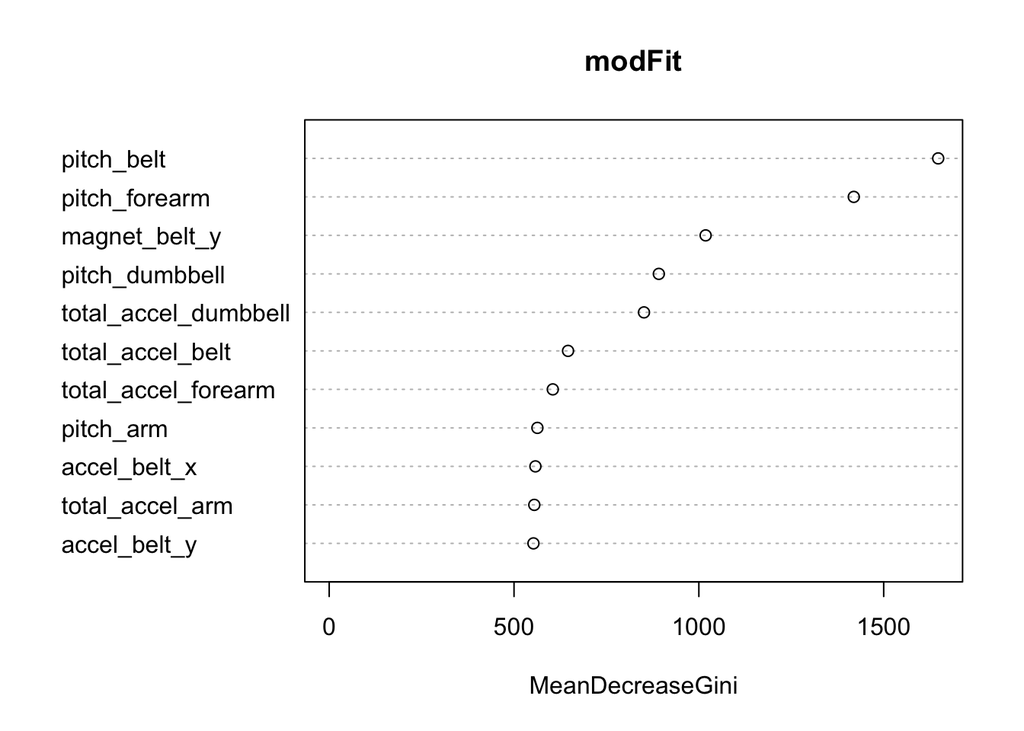

```r
varImpPlot(modFit)
```

# How the cross-validation was performed and Out-of-Bag Error (sample error)

[figure not shown]

The random forest model allows for cross-validation using the function rfcv.

```r
rf <- rfcv(trainx=training[,-12],trainy=training[,12],cv.fold=3)
```

With the above paritions, we show the effectiveness of our prediction:

```r
table(prediction,testData$classeColumn)
```

```
##
## prediction    A    B    C    D    E
##          A 2126   79   19    9    4
##          B   44 1313   38    2    4
##          C   35   75 1257   40    5
##          D   22   33   52 1232   15
##          E    5   18    2    3 1414
```

The effectivess of our prediction model based on the training data subsets is 93.5763. The attributes that were selected were adjusted based on the standard deviation to derive the approrpriate effectiveness percentage.

# Final Model

```r
model <- randomForest(classeColumn ~ ., data = training,ntree=2000)
predFinal <- predict(model,testing)
```